# Factor Variables

In a dataset, we can distinguish two types of variables: continuous and categorical.

- **continuous variable**: A continuous variable can take any values, from integer to decimal. For example, if your data deals with measuring a height, weight, or time, then you have a continuous variable.
- **categorical variable**: In descriptive statistics for categorical variable in R, the value is limited and usually based on a particular finite group. Many variables of interest in data analysis are categorical variables. For example, country, year, gender, disease status, blood type of a person: A, B, AB or O.

In this note we look at **factor** variables, which is how R represents categorical variables. **factor** in R is also known as a categorical variable that has a limited number of different values, stores both string and integer data values as levels. Factor is mostly used in statistical modeling and data analysis with R. Most often, they are predictors in a regression analysis. Occasionally, they can be the response variable as well. The behavior of certain functions changes when they encounter factors.

# 1 Important functions

- Check factors: `is.factor`, `levels`
- Create factors: `factor`, `as.factor`, `ordered`, `cut`
- Manipulate factors: `relevel`, `reorder`
- Convert factors: `as.numeric`, `as.character`, `as.factor`
- Miscellaneous: `tapply`, `by`

# 2 Check factors

## 2.1 Read data

- age: Age of the individual (Numeric)
- workclass: Class of work (Factor)
- education: Educational level of the individual (Factor)
- marital.status: Marital status of the individual (Factor) i.e. Never-married, Married-civ-spouse, …
- gender: Gender of the individual (Factor) i.e. Male or Female
- income: Target variable. Income above or below 50K (Factor) i.e. >50K, <=50K

```r
## URL of the file
adultURL <- "https://raw.githubusercontent.com/guru99-edu/R-Programming/master/adult.csv"## read in data frame
adult <- read.csv(adultURL,row.names = 1)
## check the data
head(adult)
```

```
##   age workclass    education educational.num     marital.status  race gender
## 1  25   Private         11th               7      Never-married Black   Male
## 2  38   Private      HS-grad               9 Married-civ-spouse White   Male
## 3  28 Local-gov   Assoc-acdm              12 Married-civ-spouse White   Male
## 4  44   Private Some-college              10 Married-civ-spouse Black   Male
## 5  18         ? Some-college              10      Never-married White Female
## 6  34   Private         10th               6      Never-married White   Male
##   hours.per.week income
## 1             40  <=50K
## 2             50  <=50K
## 3             40   >50K
## 4             40   >50K
## 5             30  <=50K
## 6             30  <=50K
```

## 2.2 Functions for checking factor

Is this variable a factor?

```r
is.factor(adult$workclass)
```

```
## [1] FALSE
```

We can also check by looking at the `class` of that vector.

```r
class(adult$workclass)
```

```
## [1] "character"
```

```r
adult$workclass <- as.factor(adult$workclass)
```

```r
class(adult$workclass)
```

```
## [1] "factor"
```

We can check the levels (categories) of a factor by using the `levels` or `table` command. By default, the factor levels are ordered alphabetically.

```r
levels(adult$workclass)
```

```
## [1] "?"                "Federal-gov"      "Local-gov"        "Never-worked"
## [5] "Private"          "Self-emp-inc"     "Self-emp-not-inc" "State-gov"
## [9] "Without-pay"
```

```r
table(adult$workclass)
```

```
##
##                ?      Federal-gov        Local-gov     Never-worked
##             2799             1432             3136               10
##          Private     Self-emp-inc Self-emp-not-inc        State-gov
##            33906             1695             3862             1981
##      Without-pay
##               21
```

Factors are ordered alphabetically by default. We can check if the factor variable is coded to be ordinal or not.

```r
is.ordered(adult$workclass)
```

```
## [1] FALSE
```

If it is not ordered, we can convert it to one.

```r
adult$workclass <- ordered(adult$workclass)
```

We can also check the status by looking at the class, or by using `is.ordered`.

```r
class(adult$workclass)
```

```
## [1] "ordered" "factor"
```

```r
is.ordered(adult$workclass)
```

```
## [1] TRUE
```

```r
levels(adult$workclass)
```

```
## [1] "?"                "Federal-gov"      "Local-gov"        "Never-worked"
## [5] "Private"          "Self-emp-inc"     "Self-emp-not-inc" "State-gov"
## [9] "Without-pay"
```

```r
levels(adult$workclass)[1] <- "unknown"
levels(adult$workclass)
```

```
## [1] "unknown"          "Federal-gov"      "Local-gov"        "Never-worked"
## [5] "Private"          "Self-emp-inc"     "Self-emp-not-inc" "State-gov"
## [9] "Without-pay"
```

```r
is.ordered(adult$workclass)
```

```
## [1] TRUE
```

```r
original.level=levels(adult$workclass)
new.level=original.level[c(9,1,2,3,4,5,6,8)]
workday.new=factor(adult$workclass,levels=new.level)
```

```r
table(adult$workclass)
```

```
##
##          unknown      Federal-gov        Local-gov     Never-worked
##             2799             1432             3136               10
##          Private     Self-emp-inc Self-emp-not-inc        State-gov
##            33906             1695             3862             1981
##      Without-pay
##               21
```

```r
levels(adult$workclass) <- rev(levels(adult$workclass))
```

```r
levels(adult$workclass)
```

```
## [1] "Without-pay"      "State-gov"        "Self-emp-not-inc" "Self-emp-inc"
## [5] "Private"          "Never-worked"     "Local-gov"        "Federal-gov"
## [9] "unknown"
```

For factor variables the `summary` function produces a table of counts.

```r
summary(adult$workclass)
```

```
##      Without-pay        State-gov Self-emp-not-inc     Self-emp-inc
##             2799             1432             3136               10
##          Private     Never-worked        Local-gov      Federal-gov
##            33906             1695             3862             1981
##          unknown
##               21
```

```r
summary(adult)
```

```
##       age                   workclass      education         educational.num
##  Min.   :17.00   Private         :33906   Length:48842       Min.   : 1.00
##  1st Qu.:28.00   Local-gov       : 3862   Class :character   1st Qu.: 9.00
##  Median :37.00   Self-emp-not-inc: 3136   Mode  :character   Median :10.00
##  Mean   :38.64   Without-pay     : 2799                      Mean   :10.08
##  3rd Qu.:48.00   Federal-gov     : 1981                      3rd Qu.:12.00
##  Max.   :90.00   Never-worked    : 1695                      Max.   :16.00
##                  (Other)         : 1463
##  marital.status         race              gender          hours.per.week
##  Length:48842       Length:48842       Length:48842       Min.   : 1.00
##  Class :character   Class :character   Class :character   1st Qu.:40.00
##  Mode  :character   Mode  :character   Mode  :character   Median :40.00
##                                                           Mean   :40.42
##                                                           3rd Qu.:45.00
##                                                           Max.   :99.00
##
##     income
##  Length:48842
##  Class :character
##  Mode  :character
##
##
##
##
```

Question: What is the difference between `factor` and `as.factor` when we convert a variable to a factor?

`as.factor` will leave factor levels as they are while `factor` will not:

```
## function (x)
## {
##     if (is.factor(x))
##         x
##     else if (!is.object(x) && is.integer(x)) {
##         levels <- sort(unique.default(x))
##         f <- match(x, levels)
##         levels(f) <- as.character(levels)
##         if (!is.null(nx <- names(x)))
##         names(f) <- nx
##         class(f) <- "factor"
##         f
##     }
## else factor(x)
## }
```

```r
f = factor(c("female","female"), levels = c("female", "male"))
#[1] a
#Levels: a b

factor(f)
```

```
## [1] female female
## Levels: female
```

```r
#[1] a
#Levels: a

as.factor(f)
```

```
## [1] female female
## Levels: female male
```

```r
#[1] a
#Levels: a b
```

Practice: Convert “education” and “marital.status” to factor and check the levels in the factor.

## 2.3 Creating factors

By default, when reading in spreadsheets (data frames), strings are read in as “character” or “factor”, as in the example above. Then, we can convert character to factor. This is the most common way to create factors. We can also create a factor from any vector of strings as follows using the `factor` or `as.factor` functions. Let us first create a vector of strings which are the result of four coin flips.

```r
coinflips <- c("head","tail","tail","head")
class(coinflips)
```

```
## [1] "character"
```

```r
is.factor(coinflips)
```

```
## [1] FALSE
```

We now convert it to a factor.

```r
coinflips <- as.factor(coinflips)
levels(coinflips)
```

```
## [1] "head" "tail"
```

We can also create factors from numeric variables. For example, we may want to convert a numeric BMI variable to “underweight”, “normal”, “overweight” and “obese”. For that we can use the `cut` function as follows.

```r
bmi <- 15:35
bmicat <- cut(bmi,breaks=c(10,18.5,25,30,40),
              labels=c("underweight","normal","overweight","obese"),
              ordered_result = T)
table(bmicat)
```

```
## bmicat
## underweight      normal  overweight       obese
##           4           7           5           5
```

```r
is.ordered(bmicat)
```

```
## [1] TRUE
```

```r
a=data.frame(bmi,bmicat,as.numeric(bmicat),as.character(bmicat))
View(a)
table(bmicat)
```

```
## bmicat
## underweight      normal  overweight       obese
##           4           7           5           5
```

# 3 Factor variables in linear regression

## 3.1 Signup data

Data on signups at a consulting service after emails were sent.

```r
# read in data from CSV file and examine head
signupURL <- "https://raw.githubusercontent.com/sens/smalldata/master/signups/signups.csv"
signups <- read.csv(signupURL)
head(signups)
```

```
##      date week block weekemail dayemail signups   weekday
## 1  8/6/18    1     1         0        0       0    Monday
## 2  8/7/18    1     1         0        0       1   Tuesday
## 3  8/8/18    1     1         0        0       1 Wednesday
## 4  8/9/18    1     1         0        0       0  Thursday
## 5 8/10/18    1     1         0        0       0    Friday
## 6 8/11/18    1     1         0        0       0  Saturday
```

Let us focus just on the `weekday` variable. We tabulate it.

```r
signups$weekday=as.factor(signups$weekday)
table(signups$weekday)
```

```
##
##              Friday    Monday  Saturday    Sunday  Thursday   Tuesday Wednesday
##         1        20        20        20        20        20        20        20
```

```r
levels(signups$weekday)
```

```
## [1] ""          "Friday"    "Monday"    "Saturday"  "Sunday"    "Thursday"
## [7] "Tuesday"   "Wednesday"
```

Notice that they are ordered unnaturally, and there seems to be an extra invisible category. This is a bit clearer when we use the `levels` function that shows that one of the factor levels was “empty”.

```r
## look at tail of data frame
tail(signups)
```

```
##         date week block weekemail dayemail signups   weekday
## 136 12/19/18   20     7         0        0       1 Wednesday
## 137 12/20/18   20     7         0        0       0  Thursday
## 138 12/21/18   20     7         0        0       0    Friday
## 139 12/22/18   20     7         0        0       0  Saturday
## 140 12/23/18   20     7         0        0       1    Sunday
## 141            NA    NA        NA       NA      NA
```

We can delete the last row in the data frame, but that does not get rid of the empty level (which is based on the original dataset). Besides, it is still ordered alphabetically.

```r
## remove last row
signups <- signups[-141,]
## tabluate variable
table(signups$weekday)
```

```
##
##              Friday    Monday  Saturday    Sunday  Thursday   Tuesday Wednesday
##         0        20        20        20        20        20        20        20
```

We can drop the drop unused levels from a factor by using `droplevels`.

```r
signups$weekday=droplevels(signups$weekday)
levels(signups$weekday)
```

```
## [1] "Friday"    "Monday"    "Saturday"  "Sunday"    "Thursday"  "Tuesday"
## [7] "Wednesday"
```

We can reorder the variable by using the `factor` command, and explicitly stating what order we would like them to appear.

```r
## remake the variable specifying order
signups$weekday <- factor(signups$weekday,levels=c("Monday","Tuesday","Wednesday","Thursday","Friday"))
## tabulate
table(signups$weekday)
```

```
##
##    Monday   Tuesday Wednesday  Thursday    Friday
##        20        20        20        20        20
```

## 3.2 Linear regression

Next we examine how factor variables work in linear regression. Let’s perform simple linear regression of the number of signups on the weekday variable. Note that this is also equivalent to the model fit by a one-way ANOVA.

```r
## linear regression
fit <- lm(signups~weekday,data=signups)
out <- summary(fit)
out$coefficients
```

```
##                  Estimate Std. Error    t value     Pr(>|t|)
## (Intercept)          0.85  0.2167341  3.9218557 0.0001659617
## weekdayTuesday       0.10  0.3065083  0.3262554 0.7449487701
## weekdayWednesday     0.10  0.3065083  0.3262554 0.7449487701
## weekdayThursday      0.15  0.3065083  0.4893831 0.6256985869
## weekdayFriday       -0.45  0.3065083 -1.4681492 0.1453669862
```

Notice that Monday does not appear in the linear regression. By default, in R, the intercept is the estimate of the mean for the first category (Monday), and the named categories are contrasts (difference) between the named category and the baseline category. This will be clearer if we get the means for each weekday as follows.

The `tapply` function allows you to create group summaries based on factor levels.

```r
tapply(signups$signups,signups$weekday,mean)
```

```
##    Monday   Tuesday Wednesday  Thursday    Friday
##      0.85      0.95      0.95      1.00      0.40
```

We can do the same using the `by` function.

```r
by(signups$signups,signups$weekday,mean)
```

```
## signups$weekday: Monday
## [1] 0.85
## ------------------------------------------------------------
## signups$weekday: Tuesday
## [1] 0.95
## ------------------------------------------------------------
## signups$weekday: Wednesday
## [1] 0.95
## ------------------------------------------------------------
## signups$weekday: Thursday
## [1] 1
## ------------------------------------------------------------
## signups$weekday: Friday
## [1] 0.4
```

If we want to get the individual means directly from `lm` we can run it without the intercept (with `-1` in the formula) as follows.

```r
fit1 <- lm(signups~weekday-1,data=signups)
summary(fit1)
```

```
##
## Call:
## lm(formula = signups ~ weekday - 1, data = signups)
##
## Residuals:
##    Min     1Q Median     3Q    Max
##  -1.00  -0.85   0.00   0.15   4.00
##
## Coefficients:
##                  Estimate Std. Error t value Pr(>|t|)
## weekdayMonday      0.8500     0.2167   3.922 0.000166 ***
## weekdayTuesday     0.9500     0.2167   4.383 3.02e-05 ***
## weekdayWednesday   0.9500     0.2167   4.383 3.02e-05 ***
## weekdayThursday    1.0000     0.2167   4.614 1.23e-05 ***
## weekdayFriday      0.4000     0.2167   1.846 0.068068 .
## ---
## Signif. codes:  0 '***' 0.001 '**' 0.01 '*' 0.05 '.' 0.1 ' ' 1
##
## Residual standard error: 0.9693 on 95 degrees of freedom
##   (40 observations deleted due to missingness)
## Multiple R-squared:  0.4525, Adjusted R-squared:  0.4236
## F-statistic:  15.7 on 5 and 95 DF,  p-value: 3.039e-11
```

Let’s say we want the reference category to be the middle of the week (Wednesday) instead of Monday. We can use the `relevel` command. That will effectively move Wedensday as the first category, and move up Monday and Tuesday in the ordering.

```r
signups$weekday <- relevel(signups$weekday,"Wednesday")
table(signups$weekday)
```

```
##
## Wednesday    Monday   Tuesday  Thursday    Friday
##        20        20        20        20        20
```

The linear regression output remains essentially the same, although it *looks* different because the reference category is different.

```r
out2 <- lm(signups~weekday,data=signups)
summary(out2)
```

```
##
## Call:
## lm(formula = signups ~ weekday, data = signups)
##
## Residuals:
##    Min     1Q Median     3Q    Max
##  -1.00  -0.85   0.00   0.15   4.00
##
## Coefficients:
##                   Estimate Std. Error t value Pr(>|t|)
## (Intercept)      9.500e-01  2.167e-01   4.383 3.02e-05 ***
## weekdayMonday   -1.000e-01  3.065e-01  -0.326   0.7449
## weekdayTuesday  -4.085e-16  3.065e-01   0.000   1.0000
## weekdayThursday  5.000e-02  3.065e-01   0.163   0.8708
## weekdayFriday   -5.500e-01  3.065e-01  -1.794   0.0759 .
## ---
## Signif. codes:  0 '***' 0.001 '**' 0.01 '*' 0.05 '.' 0.1 ' ' 1
##
## Residual standard error: 0.9693 on 95 degrees of freedom
##   (40 observations deleted due to missingness)
## Multiple R-squared:  0.05164,    Adjusted R-squared:  0.01171
## F-statistic: 1.293 on 4 and 95 DF,  p-value: 0.2782
```

Sometimes, we want to reorder categories based on the value of a different variable. For example, we may want to reorder the weekdays by the number of signups. We can use the `reorder` function as follows.

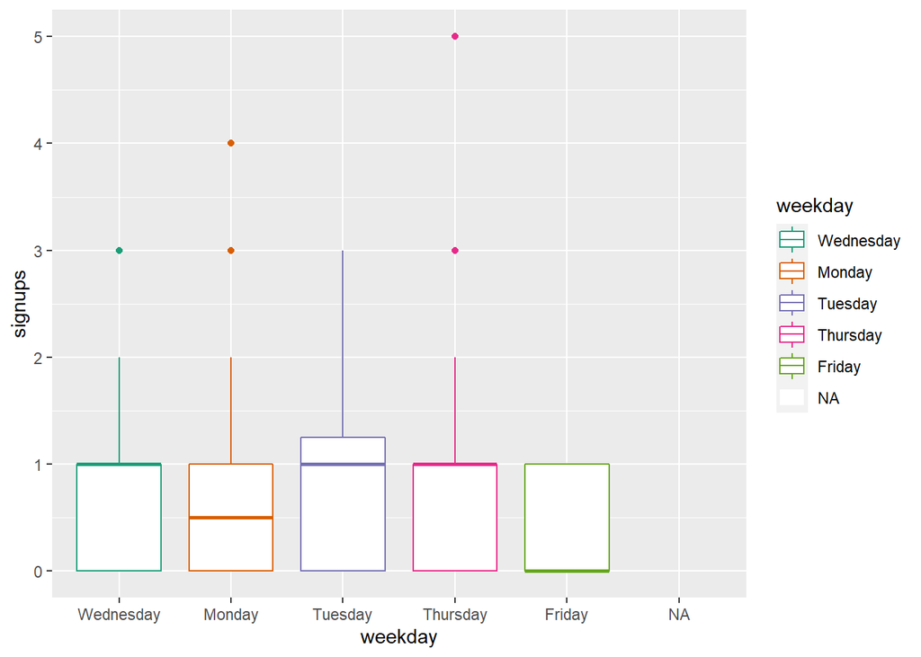

```r
library(ggplot2)
ggplot(signups, aes(x=weekday, y=signups, color=weekday)) +
  geom_boxplot()+scale_color_brewer(palette="Dark2")
```

```r
signups$weekday <- reorder(signups$weekday,signups$signups,mean)
table(signups$weekday)
```

```
##
##    Friday    Monday Wednesday   Tuesday  Thursday
##        20        20        20        20        20
```

```r
out3 <- lm(signups~weekday,data=signups)
summary(out3)
```

```
##
## Call:
## lm(formula = signups ~ weekday, data = signups)
##
## Residuals:
##    Min     1Q Median     3Q    Max
##  -1.00  -0.85   0.00   0.15   4.00
##
## Coefficients:
##                  Estimate Std. Error t value Pr(>|t|)
## (Intercept)        0.4000     0.2167   1.846   0.0681 .
## weekdayMonday      0.4500     0.3065   1.468   0.1454
## weekdayWednesday   0.5500     0.3065   1.794   0.0759 .
## weekdayTuesday     0.5500     0.3065   1.794   0.0759 .
## weekdayThursday    0.6000     0.3065   1.958   0.0532 .
## ---
## Signif. codes:  0 '***' 0.001 '**' 0.01 '*' 0.05 '.' 0.1 ' ' 1
##
## Residual standard error: 0.9693 on 95 degrees of freedom
##   (40 observations deleted due to missingness)
## Multiple R-squared:  0.05164,    Adjusted R-squared:  0.01171
## F-statistic: 1.293 on 4 and 95 DF,  p-value: 0.2782
```

## 3.3 Example

```r
hsb2 <- read.csv("https://stats.idre.ucla.edu/stat/data/hsb2.csv")
```

```r
# creating the factor variable
hsb2$female <- as.factor(hsb2$female)
is.factor(hsb2$female)
```

```
## [1] TRUE
```

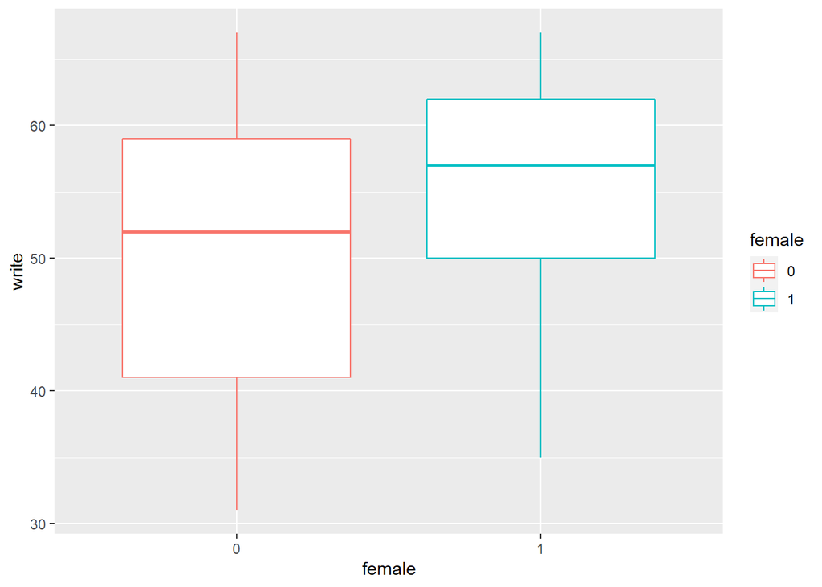

```r
ggplot(hsb2, aes(x=female, y=write, color=female)) +
  geom_boxplot()
```

```r
summary(lm(write ~ female, data = hsb2))
```

```
##
## Call:
## lm(formula = write ~ female, data = hsb2)
##
## Residuals:
##     Min      1Q  Median      3Q     Max
## -19.991  -6.371   1.879   7.009  16.879
##
## Coefficients:
##             Estimate Std. Error t value Pr(>|t|)
## (Intercept)  50.1209     0.9628  52.057  < 2e-16 ***
## female1       4.8699     1.3042   3.734 0.000246 ***
## ---
## Signif. codes:  0 '***' 0.001 '**' 0.01 '*' 0.05 '.' 0.1 ' ' 1
##
## Residual standard error: 9.185 on 198 degrees of freedom
## Multiple R-squared:  0.06579,    Adjusted R-squared:  0.06107
## F-statistic: 13.94 on 1 and 198 DF,  p-value: 0.0002463
```

Practice: Please use the `lm` function to perform a regression for testing association between **read** and **gender**, and get a summary of the regression using the summary function.

```r
fit=lm(read ~ female, data = hsb2)
summary(fit)
```

```
##
## Call:
## lm(formula = read ~ female, data = hsb2)
##
## Residuals:
##     Min      1Q  Median      3Q     Max
## -23.734  -7.734  -1.734   8.266  24.266
##
## Coefficients:
##             Estimate Std. Error t value Pr(>|t|)
## (Intercept)   52.824      1.076  49.093   <2e-16 ***
## female1       -1.090      1.458  -0.748    0.455
## ---
## Signif. codes:  0 '***' 0.001 '**' 0.01 '*' 0.05 '.' 0.1 ' ' 1
##
## Residual standard error: 10.26 on 198 degrees of freedom
## Multiple R-squared:  0.002818,   Adjusted R-squared:  -0.002218
## F-statistic: 0.5595 on 1 and 198 DF,  p-value: 0.4553
```

```r
fit=lm(write ~ factor(female)+factor(race)+read+factor(female)*read, data = hsb2)
summary(fit)
```

```
##
## Call:
## lm(formula = write ~ factor(female) + factor(race) + read + factor(female) *
##     read, data = hsb2)
##
## Residuals:
##      Min       1Q   Median       3Q      Max
## -17.9798  -4.0624   0.1607   4.8232  14.8232
##
## Coefficients:
##                      Estimate Std. Error t value Pr(>|t|)
## (Intercept)          15.60468    3.86330   4.039 7.74e-05 ***
## factor(female)1      12.31228    5.16544   2.384  0.01811 *
## factor(race)2         7.31587    2.57121   2.845  0.00492 **
## factor(race)3         0.56267    2.12351   0.265  0.79131
## factor(race)4         3.32604    1.58421   2.100  0.03707 *
## read                  0.60098    0.07153   8.402 9.44e-15 ***
## factor(female)1:read -0.13475    0.09683  -1.392  0.16567
## ---
## Signif. codes:  0 '***' 0.001 '**' 0.01 '*' 0.05 '.' 0.1 ' ' 1
##
## Residual standard error: 6.981 on 193 degrees of freedom
## Multiple R-squared:  0.4739, Adjusted R-squared:  0.4576
## F-statistic: 28.98 on 6 and 193 DF,  p-value: < 2.2e-16
```